# R Notebook

# 6.118

## Planning another test to compare consumption.

### A) Solution:

```r
#Here, level of significance
a = .05

# As it is a one-tailed test
qnorm(a)
```

```
[1] -1.644854
```

*So, if Z < -1.644854 then we can reject the null hypothesis*

### B) Solution:

```r
#Here
n = 100 # sample size
m = 286 # mean
S = 155 # standard deviation of the population
s = S/sqrt(n) # standard deviation of the sample
a = .05 # level of significance
z = qnorm(a)
# As Z = (x -mean)/standard deviation
# So, x = Z* standard deviation + mean

x_b = z*s+m
x_b
```

```
[1] 260.5048
```

*So, if mean of sample is less than 260.5048 then we can reject the null hypothesis*

### C) Solution:

```r
#Here
n = 100 # sample size
m = 271 # alternate mean
S = 155 # standard deviation of the population
s = S/sqrt(n) # standard deviation of the sample
x_c = x_b
# As Z = (x bar-mean)/standard deviation
z = (x_c-m)/s
# As it is a one-tailed test
pnorm(z)
```

```
[1] 0.2491675
```

*the probability that x¯ will fall in the region defined in part (b) is 0.2491675*

### D) Solution:

```r
# Here
m0 = 286 #old mean
m1 = 271 # new mean
a = .05 # level of significance
S = 155 # standard deviation of the population
n = 100 # sample size
s = S/sqrt(n) # standard deviation of the sample
z1 = qnorm(1-a)
# We know that Power   =   P[Z > Z1 − |(m1 − m0)| / (S / √n)]
p = 1- pnorm(z1-(abs(m1-m0)/s))
p
```

```
[1] 0.2491675
```

*So the power for n=100 is pretty low (.249) and not adequate for which we need bigger sample size.*

### E) Solution:

```r
#Here
m0 = 286 #old mean
m1 = 271 # new mean
S = 155 # standard deviation of the population
a = .05 # level of significance
z1 = qnorm(1-a)
p = .8 # desired power
z2 = qnorm(p)
z1
```

```
[1] 1.644854
```

```r
z2
```

```
[1] 0.8416212
```

```r
# we know sample size, n = (z1+z2)^2*S^2/(m0-m1)^2

n = (z1+z2)^2*S^2/(m1-m0)^2
n
```

```
[1] 660.1597
```

*So we would need a sample size of 660 or 661.* *The results were validated by Statistical applet https://digitalfirst.bfwpub.com/stats_applet/stats_applet_9_power.html*

# 6.124

## Stress by occupation.

### A) Solution:

```r
df = data.frame("Occupation" = c("Professional", "Managerial", "Administrative","Sales", 'Mechanical', 'Service', 'Operator', 'Farm'),
                "p" =c(.23,.22,.17,.15,.12,.13,.12,.08),"n"=c(2447,2552,2309,1811,1979,2592,2782,571))
df
```

| Occupation | p | n |
| --- | --- | --- |
| Professional | 0.23 | 2447 |
| Managerial | 0.22 | 2552 |
| Administrative | 0.17 | 2309 |
| Sales | 0.15 | 1811 |
| Mechanical | 0.12 | 1979 |
| Service | 0.13 | 2592 |
| Operator | 0.12 | 2782 |
| Farm | 0.08 | 571 |

```r
# with 95% confidence level for a two tailed test
a = .05
# So confidence level c = 1 - (a/2)
c = 1 - (a/2)
c
```

```
[1] 0.975
```

```r
# We know that CI (Proportion) = (P^ - Zc*sqrt(p^(1-p^)/n), P^ + Zc*sqrt(p^(1-p^)/n))
df$CI_left = df$p-qnorm(c)*sqrt(df$p*(1-df$p)/df$n)
df$CI_right = df$p+qnorm(c)*sqrt(df$p*(1-df$p)/df$n)
df
```

| Occupation | p | n | CI_left | CI_right |
| --- | --- | --- | --- | --- |
| Professional | 0.23 | 2447 | 0.21332598 | 0.2466740 |
| Managerial | 0.22 | 2552 | 0.20392813 | 0.2360719 |
| Administrative | 0.17 | 2309 | 0.15467856 | 0.1853214 |
| Sales | 0.15 | 1811 | 0.13355462 | 0.1664454 |
| Mechanical | 0.12 | 1979 | 0.10568283 | 0.1343172 |
| Service | 0.13 | 2592 | 0.11705322 | 0.1429468 |
| Operator | 0.12 | 2782 | 0.10792460 | 0.1320754 |
| Farm | 0.08 | 571 | 0.05774801 | 0.1022520 |

```r
# So the confidence intervals are
print(paste('(',df$CI_left,',',df$CI_right,')'))
```

```
[1] "( 0.213325977356449 , 0.246674022643551 )"  "( 0.203928130486239 , 0.236071869513761 )"  "( 0.154678558354342 , 0.185321441645658 )"
[4] "( 0.13355461828991 , 0.16644538171009 )"    "( 0.105682830946921 , 0.134317169053079 )"  "( 0.117053216225026 , 0.142946783774974 )"
[7] "( 0.107924601069392 , 0.132075398930608 )"  "( 0.0577480054927639 , 0.102251994507236 )"
```

### B) Solution:

```r
# five-number summary
summary(df)
```

```
  Occupation              p                n           CI_left           CI_right
 Length:8           Min.   :0.0800   Min.   : 571   Min.   :0.05775   Min.   :0.1023
 Class :character   1st Qu.:0.1200   1st Qu.:1937   1st Qu.:0.10736   1st Qu.:0.1338
 Mode  :character   Median :0.1400   Median :2378   Median :0.12530   Median :0.1547
                    Mean   :0.1525   Mean   :2130   Mean   :0.13674   Mean   :0.1683
                    3rd Qu.:0.1825   3rd Qu.:2562   3rd Qu.:0.16699   3rd Qu.:0.1980
                    Max.   :0.2300   Max.   :2782   Max.   :0.21333   Max.   :0.2467
```

*Mechanical and operator appear to have similar stress levels. Moreover, managerial and professionals also seem to have pretty similar stress levels.*

### C) Solution:

*My friend might be concerned with whether np>= 10 and n(1-p)>= 10 is satisfied or not.*

# 6.128

## Effect of sample size on significance.

### Solution:

```r
# Here
m0 = 0 # null hypothesis mean
xbar = 4 # new mean
S = 14 # standard deviation
a = .05 # level of significance
```

```r
# for n = 10
n = 10
s = S/sqrt(n)
print(paste("Z-value =",(xbar-m0)/s))
```

```
[1] "Z-value = 0.903507902905251"
```

```r
print(paste("P-value =",pnorm((xbar-m0)/s, lower.tail = FALSE)))
```

```
[1] "P-value = 0.183128197912392"
```

```r
# for n = 20
n = 20
s = S/sqrt(n)
print(paste("Z-value =",(xbar-m0)/s))
```

```
[1] "Z-value = 1.27775312999988"
```

```r
print(paste("P-value =",pnorm((xbar-m0)/s, lower.tail = FALSE)))
```

```
[1] "P-value = 0.1006682426437"
```

```r
# for n = 30
n = 30
s = S/sqrt(n)
print(paste("Z-value =",(xbar-m0)/s))
```

```
[1] "Z-value = 1.5649215928719"
```

```r
print(paste("P-value =",pnorm((xbar-m0)/s, lower.tail = FALSE)))
```

```
[1] "P-value = 0.0588006474973132"
```

```r
# for n = 40
n = 40
s = S/sqrt(n)
print(paste("Z-value =",(xbar-m0)/s))
```

```
[1] "Z-value = 1.8070158058105"
```

```r
print(paste("P-value =",pnorm((xbar-m0)/s, lower.tail = FALSE)))
```

```
[1] "P-value = 0.0353799074015287"
```

```r
# for n = 50
n = 50
s = S/sqrt(n)
print(paste("Z-value =",(xbar-m0)/s))
```

```
[1] "Z-value = 2.02030508910442"
```

```r
print(paste("P-value =",pnorm((xbar-m0)/s, lower.tail = FALSE)))
```

```
[1] "P-value = 0.0216758756304313"
```

*With increasing sample size, p-values decrease if we keep the sample mean the same in all cases. This shows that the increase in sample size gives us more and more evidence against null hypothesis and hence increases the probability of rejecting null hypothesis. For example, in the case above, for the sample size 10,20 and 30 , we will not reject null because p-value > 0.05 but for the case of 40 and 50, we will reject null.*

# 6.129

## Blood phosphorus level in dialysis patients.

### A) Solution:

```r
arr = c(5.4,5.2,4.5,4.9,5.7,6.3)
xbar = mean(arr)
xbar
```

```
[1] 5.333333
```

```r
# Here
S = .9 # standard deviation of the population
n = length(arr) # sample size
n
```

```
[1] 6
```

```r
# We know that CI (Proportion) = (P^ - Zc*sqrt(p^(1-p^)/n), P^ + Zc*sqrt(p^(1-p^)/n))
# With 95% confidence level for a two-tailed test
a = .05
# and confidence level c = 1 - a/2
c = 1 - a/2
c
```

```
[1] 0.975
```

```r
# So, Confidence interval for the mean blood phosphorus level
print(paste('(',xbar-qnorm(c)*S/sqrt(n),',',xbar+qnorm(c)*S/sqrt(n),')'))
```

```
[1] "( 4.61319658188004 , 6.05347008478663 )"
```

### B) Solution:

*Since the confidence interval from part (a) includes 4.8 and the minimum value of possible mean is less than 4.8, there is not sufficient evidence that this patient has a mean phosphorus level that exceeds 4.8.*

# 6.130

## Cellulose content in alfalfa hay.

### A) Solution:

```r
# We know that CI (Proportion) = (P^ - Zc*sqrt(p^(1-p^)/n), P^ + Zc*sqrt(p^(1-p^)/n))
# With 90% confidence level for a two-tailed test
a = .1
# and confidence level c = 1 - a/2
c = 1 - a/2
c
```

```
[1] 0.95
```

```r
# Here
S = 8 # standard deviation of the population
xbar = 145 # mean
n = 15 # sample size
```

```r
# So, Confidence interval for the mean cellulose content in the population
print(paste('(',xbar-qnorm(c)*S/sqrt(n),',',xbar+qnorm(c)*S/sqrt(n),')'))
```

```
[1] "( 141.602404957796 , 148.397595042204 )"
```

### B) Solution:

*Here H0: m = 140* *H1: m > 140*

```r
# So
m = 140 # mean of the null hypothesis
# We know that test statics Z = (xbar - m)/(S/sqrt(n))
Z = (xbar - m)/(S/sqrt(n))
Z
```

```
[1] 2.420615
```

```r
# So P- value of P(Z > 2.420615)

pnorm(Z, lower.tail = FALSE)
```

```
[1] 0.007747147
```

*As the p-value is less than level of significance we can reject the null hypothesis.*

### C) Solution:

*The main assumption we are taking is that the underlying population is normal and standard deviation is 8 mg/g.* *The second assumption we need to make that all the 15 sample are taken randomly, so that they can be independent.*

# 6.133

## CEO pay.

### A) Solution:

```r
# Here
xbar = 6.9 # mean of the sample
S = 55 # Standard deviation
n = 104 # Sample size
m = 0 # mean of null hypothesis
```

```r
Z = (xbar-m)/(S/sqrt(n))
Z
```

```
[1] 1.27939
```

```r
# function for shading area in a graph
colorArea <- function(from, to, density, ..., col="lightgray", dens=NULL){
    y_seq <- seq(from, to, length.out=500)
    d <- c(0, density(y_seq, ...), 0)
    polygon(c(from, y_seq, to), d, col=col, density=dens)
}
```

```r
curve(dnorm(x, mean = 0, sd = 1), from = -3, to = 3, yaxt = 'n', xlab = "Standard deviation", main= "Normal distribution of average pay increase of CEOs ")
colorArea(from=-3, to=Z, dnorm)
```

```r
text(Z+.3,0.2, round(Z,2))
text(0.4,0.2, "Mean")
```

```r
abline(v=0, col="red")
abline(v=Z, col="purple")
```

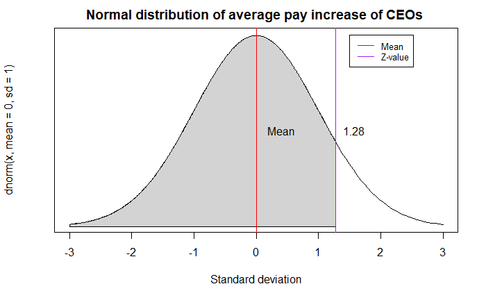

```r
legend(1.5, .4, legend=c("Mean", "Z-value"),
       col=c("red", "purple"), lty=1:1, cex=0.8)
```

```r
#axis(1, at = c(-3,-2,-1,0,1,2,3), labels = c('-3S', '-2S', '-S','mean','S','2S','3S'))
```

### B) Solution:

```r
# So the P-value is
P = pnorm(Z, lower.tail = FALSE)
P
```

```
[1] 0.1003798
```

### C) Solution:

*As the P-value is greater than a = 0.05, we cannot reject the null hypothesis. Moreover, the study does not give strong evidence that the mean compensation of all CEOs went up.*